# ML Template

Jai Jeffryes

12/29/2019

# 1 Template introduction

Chapter 2 of [An Introduction to Statistical Learning with Applications in R](http://faculty.marshall.usc.edu/gareth-james/ISL/), explores sample advertising data by answering seven questions. This template recapitulates those questions using data about cats from `MASS` R package. Substitute other datasets to reuse the approach and the code.

## 1.1 References

- James, G., Witten, D., Hastie, T., and Tibshirani, R. (2013) *An Introduction to Statistical Learning with Applications in R*. New York: Springer.
- Venables W. N,, Ripley B. D. (2002) *Modern Applied Statistics with S*, Fourth edition. New York: Springer. ISBN 0-387-95457-0, http://www.stats.ox.ac.uk/pub/MASS4.

# 2 Set up

## 2.1 Load libraries

```r
library(car)   # Variance inflation factor.
library(MASS)  # Cats dataset.
```

## 2.2 Load data

```r
data(cats)
# Use a generic name to support code reuse.
dataset <- cats
rm(cats)
gc()
```

```
##           used (Mb) gc trigger (Mb) max used (Mb)
## Ncells  620742 33.2    1224620 65.5  1140253 60.9
## Vcells 1070030  8.2    8388608 64.0  1752684 13.4
```

# 3 Seven questions

## 3.1 Is there a relationship between predictors and a response

- Fit a multiple regression model.
- Test the null hypothesis. $H_0$: Each predictor = 0. Evaluate the p-value of the $F$ statistic.

```r
set.seed(42)
lm.fit <- lm(Hwt ~ Bwt + Sex, data = dataset)
lm.summary <- summary(lm.fit)
lm.summary
```

```
##
## Call:
## lm(formula = Hwt ~ Bwt + Sex, data = dataset)
##
## Residuals:
##     Min      1Q  Median      3Q     Max
## -3.5833 -0.9700 -0.0948  1.0432  5.1016
##
## Coefficients:
##             Estimate Std. Error t value Pr(>|t|)
## (Intercept)  -0.4149     0.7273  -0.571    0.569
## Bwt           4.0758     0.2948  13.826   <2e-16 ***
## SexM         -0.0821     0.3040  -0.270    0.788
## ---
## Signif. codes:  0 '***' 0.001 '**' 0.01 '*' 0.05 '.' 0.1 ' ' 1
##
## Residual standard error: 1.457 on 141 degrees of freedom
## Multiple R-squared:  0.6468, Adjusted R-squared:  0.6418
## F-statistic: 129.1 on 2 and 141 DF,  p-value: < 2.2e-16
```

### 3.1.1 Conclusion for null hypothesis

The $F$-statistic is far from 1 and its p-value is close to 0. We reject the null hypothesis and accept the alternative hypothesis, concluding there is a relationship of statistical significance between the predictors and the response.

## 3.2 How strong is the relationship

There are two accuracy measures.

1. Residual standard error (RSE) measures the standard deviation of the response from the population regression line. Comparing RSE to the mean response yields percentage error.
2. $R^2$ gives you percentage of variability in the response explained by the predictors.

```r
# RSE
# lm.summary$sigma

# Mean response
response_mean <- mean(cats$Hwt)

# Percentage error
error_percent <- (lm.summary$sigma / response_mean) * 100

# R squared
# lm.summary$r.squared
```

- RSE: 1.4571378.
- Mean response: 10.6305556.
- Mean error of prediction: 13.7070714%.
- $R^2$: 0.6468035.

### 3.2.1 Conclusion for strength of relationship

Our predictions differ, on average, from the true value by 1.46 g. on an average heart weight of 10.63 g, indicating an error rate of 14%. The predictors explain 65% of the variance in heart weight.

## 3.3 Which predictors contribute to the response

Examine the p-values associated with each predictor’s t-statistic.

### 3.3.1 Conclusion for contributing predictors

- Body weight is related to heart weight.
- Sex is not.

## 3.4 How large is the effect of each predictor on the response

- Examine confidence intervals. Are they narrow and far from zero, or do they include zero, making them statistically insignificant.
- Evaluate variance inflation factor for evidence of collinearity. A value of 1 indicates none.
- Run separate simple linear regressions.

```r
confint(lm.fit)
```

```
##                  2.5 %   97.5 %
## (Intercept) -1.8528230 1.022918
## Bwt          3.4929923 4.658546
## SexM        -0.6831776 0.518984
```

```r
vif(lm.fit)
```

```
##      Bwt      Sex
## 1.378441 1.378441
```

```r
summary(lm(Hwt ~ Bwt, data = dataset))
```

```
##
## Call:
## lm(formula = Hwt ~ Bwt, data = dataset)
##
## Residuals:
##     Min      1Q  Median      3Q     Max
## -3.5694 -0.9634 -0.0921  1.0426  5.1238
##
## Coefficients:
##             Estimate Std. Error t value Pr(>|t|)
## (Intercept)  -0.3567     0.6923  -0.515    0.607
## Bwt           4.0341     0.2503  16.119   <2e-16 ***
## ---
## Signif. codes:  0 '***' 0.001 '**' 0.01 '*' 0.05 '.' 0.1 ' ' 1
##
## Residual standard error: 1.452 on 142 degrees of freedom
## Multiple R-squared:  0.6466, Adjusted R-squared:  0.6441
## F-statistic: 259.8 on 1 and 142 DF,  p-value: < 2.2e-16
```

```r
summary(lm(Hwt ~ Sex, data = dataset))
```

```
##
## Call:
## lm(formula = Hwt ~ Sex, data = dataset)
##
## Residuals:
##     Min      1Q  Median      3Q     Max
## -4.8227 -1.7227  0.0273  1.2273  9.1773
##
## Coefficients:
##             Estimate Std. Error t value Pr(>|t|)
## (Intercept)   9.2021     0.3251  28.308  < 2e-16 ***
## SexM          2.1206     0.3961   5.354 3.38e-07 ***
## ---
## Signif. codes:  0 '***' 0.001 '**' 0.01 '*' 0.05 '.' 0.1 ' ' 1
##
## Residual standard error: 2.229 on 142 degrees of freedom
## Multiple R-squared:  0.168,  Adjusted R-squared:  0.1621
## F-statistic: 28.66 on 1 and 142 DF,  p-value: 3.38e-07
```

### 3.4.1 Conclusion for effects

- The confidence interval for body weight appears narrow and it is far from 0, providing evidence that it is related to heart weight.
- The confidence interval for sex includes 0, indicating it is statistically insignificant for a given body weight.
- Variance inflation factors are near 1, so there is no evidence of collinearity to explain the confidence interval for sex.
- Body weight alone has a strong association. It’s p-value is near zero, and its $R^2$ is 0.6466, very close to $R^2$ from the multiple regression model, which is 0.6468035.
- Sex alone has statistical significance. The p-value of its $F$ statistic is low, so there is a relationship, and the p-value of the predictor is low, so it has significance when body weight is ignored. However, the effect is weaker. Its $R^2$ indicates that sex alone accounts for only 17% of the variance in heart weight.

## 3.5 How accurately can we predict future responses

- Predict the average response. For a certain percentage of datasets, the confidence interval contains the true average of the response. In other words, the value on the regression line.
- Predict an individual response. For a certain percentage of datasets, the prediction interval contains the true value of the response. It accounts for not only the reducible error, but also the uncertainty surrounding the response for a particular case. In other words, the interval includes the result of the estimated average plus residual or $\epsilon$.

(Should I drop the predictor of sex here?)

```r
# Produce confidence intervals and prediction intervals for the prediction of medv for a given value of lstat.
input.predict <- data.frame(Bwt = c(3, 3, 5, 5, 10, 10),
                            Sex = c("M", "F", "M", "F", "M", "F"))

# Test data.
input.predict
```

```
##   Bwt Sex
## 1   3   M
## 2   3   F
## 3   5   M
## 4   5   F
## 5  10   M
## 6  10   F
```

```r
# Confidence intervals.
predict(lm.fit, input.predict, interval = "confidence")
```

```
##        fit      lwr      upr
## 1 11.73026 11.43202 12.02849
## 2 11.81235 11.25034 12.37436
## 3 19.88180 18.62350 21.14009
## 4 19.96389 18.36878 21.55901
## 5 40.26064 36.11260 44.40868
## 6 40.34274 35.87029 44.81518
```

```r
# Prediction intervals.
predict(lm.fit, input.predict, interval = "prediction")
```

```
##        fit       lwr      upr
## 1 11.73026  8.834199 14.62632
## 2 11.81235  8.877381 14.74733
## 3 19.88180 16.738306 23.02528
## 4 19.96389 16.671080 23.25670
## 5 40.26064 35.210448 45.31083
## 6 40.34274 35.022871 45.66260
```

## 3.6 Is the relationship linear

Residual plots. Try transformations of predictors to accommodate non-linear relationships.

- Residuals vs. fitted values. In simple regression this is residuals to predictor. We wish to see no pattern.
- Normal Q-Q.
- Scale-location.
- Residuals vs. leverage.
- Try transformations to reduce patterns. $log X$, $\sqrt{X}$, $X^2$, or higher polynomials using `poly()`.

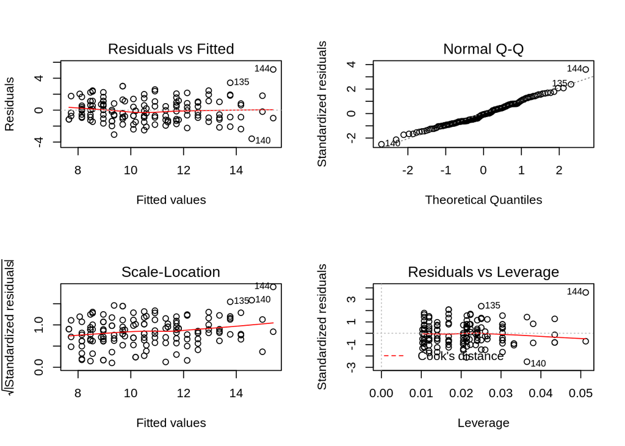

```r
par.old <- par(no.readonly = TRUE)
par(mfrow = c(2,2))
plot(lm.fit)
```

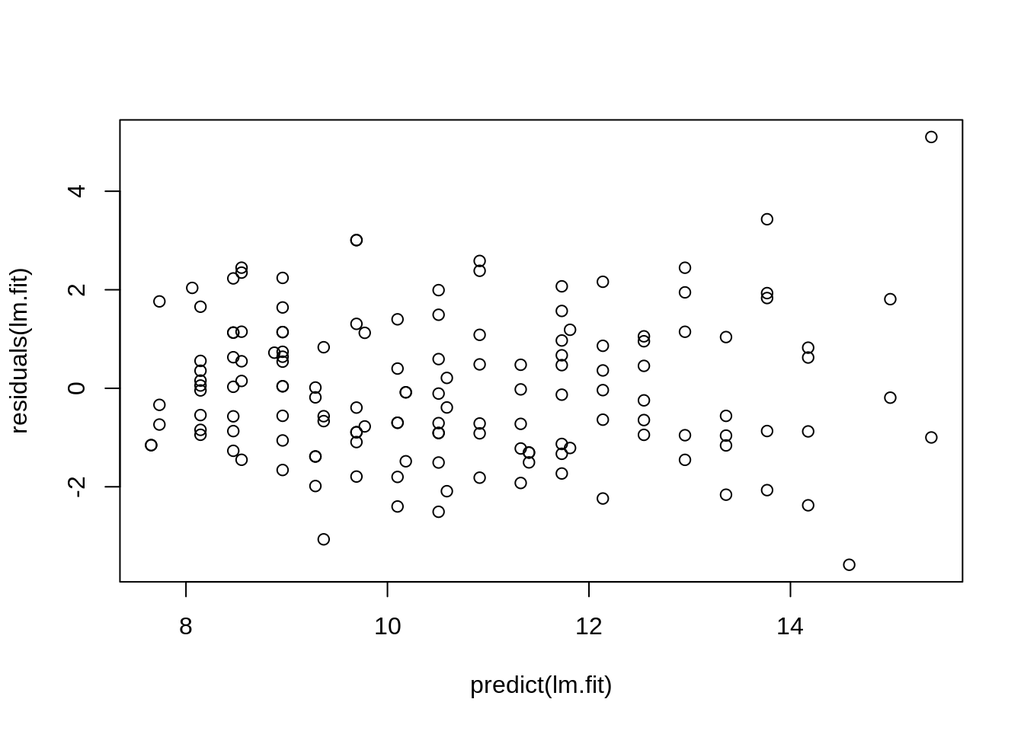

```r
par(par.old)

plot(predict(lm.fit), residuals(lm.fit))
```

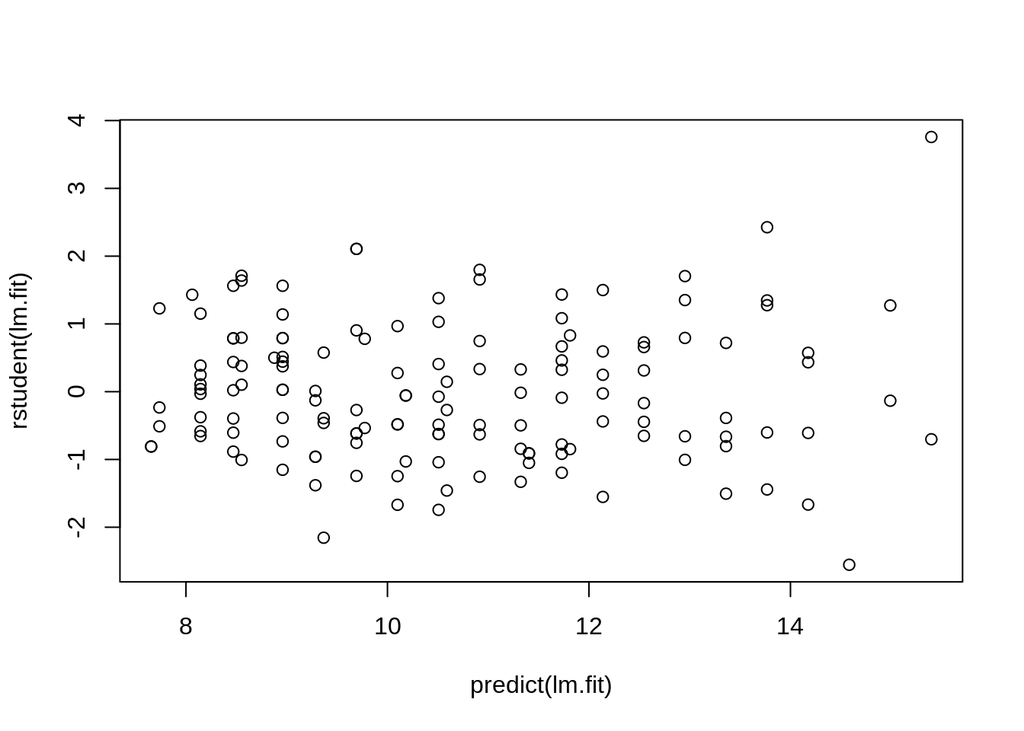

```r
plot(predict(lm.fit), rstudent(lm.fit))
```

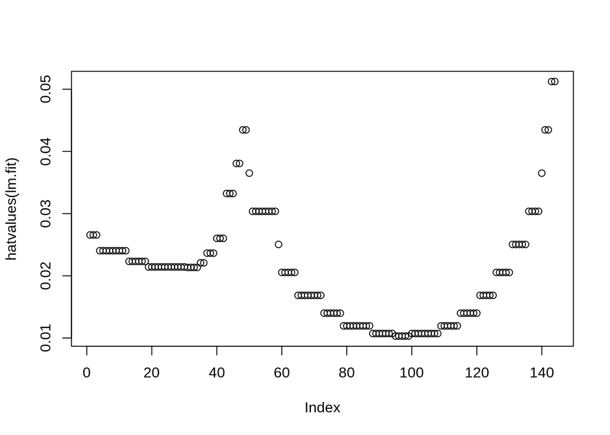

```r
# Compute leverage statistics.
plot(hatvalues (lm.fit))
```

```r
which.max(hatvalues (lm.fit))
```

```
## 143
## 143
```

### 3.6.2 Transformations

Though the template doesn’t need them, include the code for use later.

I want to show heteroscedacity in a plot.

```r
# Fits for: log, square root, square, and polynomials.
lm.log.fit <- lm(Hwt ~ . + log(Bwt), data = dataset)
lm.sqrt.fit <- lm(Hwt ~ . + sqrt(Bwt), data = dataset)
lm.sq.fit <- lm(Hwt ~ . + I(Bwt^2), data = dataset)
lm.poly.fit <- lm(Hwt ~ . + poly(Bwt, 5), data = dataset)

# Analysis of variance
anova(lm.fit, lm.log.fit, lm.sqrt.fit, lm.sq.fit, lm.poly.fit)
```

```
## Analysis of Variance Table
##
## Model 1: Hwt ~ Bwt + Sex
## Model 2: Hwt ~ Sex + Bwt + log(Bwt)
## Model 3: Hwt ~ Sex + Bwt + sqrt(Bwt)
## Model 4: Hwt ~ Sex + Bwt + I(Bwt^2)
## Model 5: Hwt ~ Sex + Bwt + poly(Bwt, 5)
##   Res.Df    RSS Df Sum of Sq      F  Pr(>F)
## 1    141 299.38
## 2    140 293.72  1    5.6620 2.7865 0.09734 .
## 3    140 293.59  0    0.1288
## 4    140 293.28  0    0.3078
## 5    137 278.37  3   14.9100 2.4460 0.06655 .
## ---
## Signif. codes:  0 '***' 0.001 '**' 0.01 '*' 0.05 '.' 0.1 ' ' 1
```

```r
# Review summaries and diagnostic plots
par.old <- par(no.readonly = TRUE)
par(mfrow = c(2,2))

summary(lm.fit)
```

```
##
## Call:
## lm(formula = Hwt ~ Bwt + Sex, data = dataset)
##
## Residuals:
##     Min      1Q  Median      3Q     Max
## -3.5833 -0.9700 -0.0948  1.0432  5.1016
##
## Coefficients:
##             Estimate Std. Error t value Pr(>|t|)
## (Intercept)  -0.4149     0.7273  -0.571    0.569
## Bwt           4.0758     0.2948  13.826   <2e-16 ***
## SexM         -0.0821     0.3040  -0.270    0.788
## ---
## Signif. codes:  0 '***' 0.001 '**' 0.01 '*' 0.05 '.' 0.1 ' ' 1
##
## Residual standard error: 1.457 on 141 degrees of freedom
## Multiple R-squared:  0.6468, Adjusted R-squared:  0.6418
## F-statistic: 129.1 on 2 and 141 DF,  p-value: < 2.2e-16
```

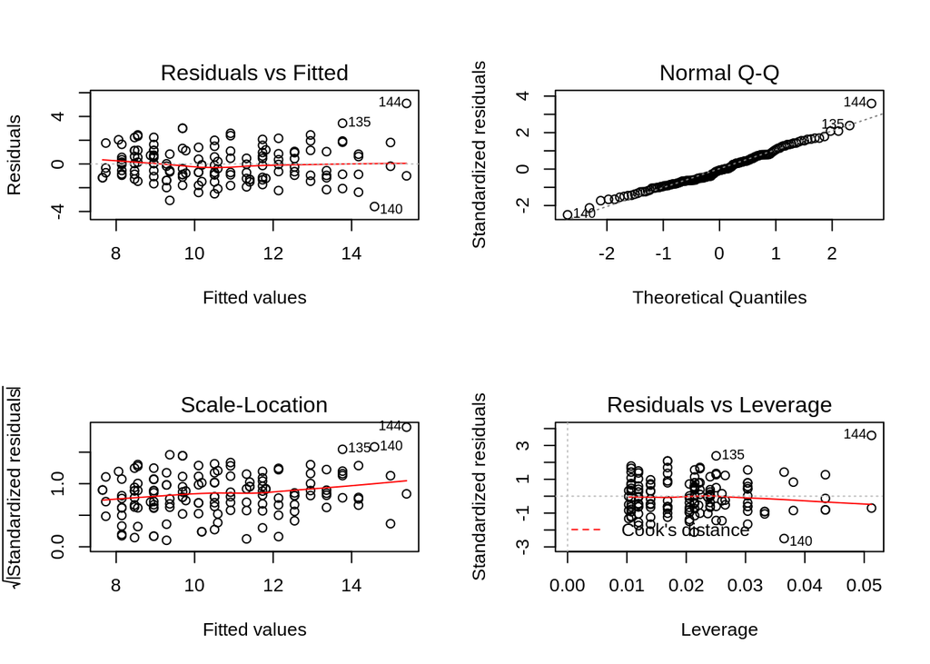

```r
plot(lm.fit)
```

```r
summary(lm.log.fit)
```

```
##
## Call:
## lm(formula = Hwt ~ . + log(Bwt), data = dataset)
##
## Residuals:
##     Min      1Q  Median      3Q     Max
## -3.9547 -1.0422 -0.1409  0.9843  4.4859
##
## Coefficients:
##               Estimate Std. Error t value Pr(>|t|)
## (Intercept)  -0.260231   0.729091  -0.357  0.72168
## SexM          0.009062   0.307284   0.029  0.97652
## Bwt           8.754329   2.862960   3.058  0.00267 **
## log(Bwt)    -13.135165   7.995613  -1.643  0.10267
## ---
## Signif. codes:  0 '***' 0.001 '**' 0.01 '*' 0.05 '.' 0.1 ' ' 1
##
## Residual standard error: 1.448 on 140 degrees of freedom
## Multiple R-squared:  0.6535, Adjusted R-squared:  0.6461
## F-statistic: 88.01 on 3 and 140 DF,  p-value: < 2.2e-16
```

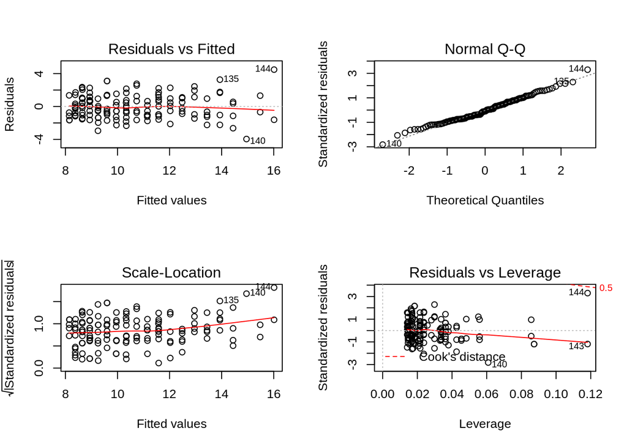

```r
plot(lm.log.fit)
```

```r
summary(lm.sqrt.fit)
```

```
##
## Call:
## lm(formula = Hwt ~ . + sqrt(Bwt), data = dataset)
##
## Residuals:
##     Min      1Q  Median      3Q     Max
## -3.9655 -1.0364 -0.1423  0.9917  4.4571
##
## Coefficients:
##              Estimate Std. Error t value Pr(>|t|)
## (Intercept)  26.10768   15.97717   1.634   0.1045
## SexM          0.01105    0.30732   0.036   0.9714
## Bwt          13.57025    5.72110   2.372   0.0191 *
## sqrt(Bwt)   -31.90117   19.19751  -1.662   0.0988 .
## ---
## Signif. codes:  0 '***' 0.001 '**' 0.01 '*' 0.05 '.' 0.1 ' ' 1
##
## Residual standard error: 1.448 on 140 degrees of freedom
## Multiple R-squared:  0.6536, Adjusted R-squared:  0.6462
## F-statistic: 88.07 on 3 and 140 DF,  p-value: < 2.2e-16
```

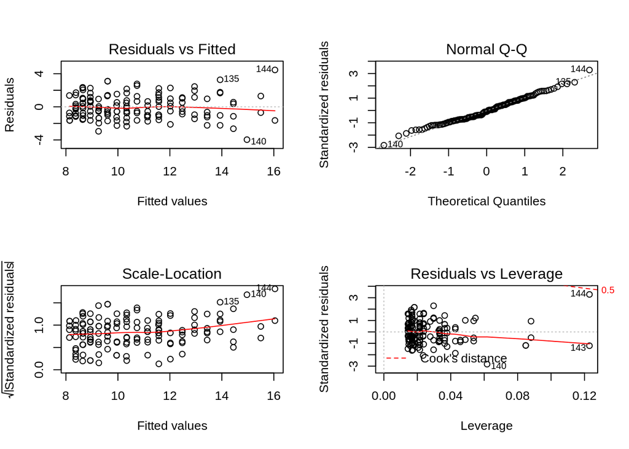

```r
plot(lm.sqrt.fit)
```

```r
summary(lm.sq.fit)
```

```
##
## Call:
## lm(formula = Hwt ~ . + I(Bwt^2), data = dataset)
##
## Residuals:
##     Min      1Q  Median      3Q     Max
## -3.9933 -1.0286 -0.1414  1.0134  4.3705
##
## Coefficients:
##             Estimate Std. Error t value Pr(>|t|)
## (Intercept)   6.3717     4.0427   1.576   0.1173
## SexM          0.0156     0.3074   0.051   0.9596
## Bwt          -0.8572     2.9059  -0.295   0.7684
## I(Bwt^2)      0.8603     0.5042   1.706   0.0902 .
## ---
## Signif. codes:  0 '***' 0.001 '**' 0.01 '*' 0.05 '.' 0.1 ' ' 1
##
## Residual standard error: 1.447 on 140 degrees of freedom
## Multiple R-squared:  0.654,  Adjusted R-squared:  0.6466
## F-statistic: 88.21 on 3 and 140 DF,  p-value: < 2.2e-16
```

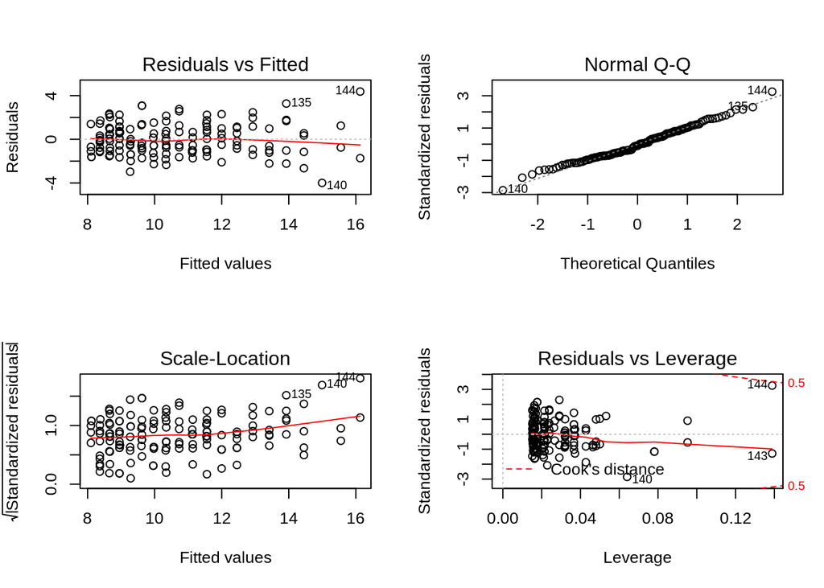

```r
plot(lm.sq.fit)
```

```r
summary(lm.poly.fit)
```

```
##
## Call:
## lm(formula = Hwt ~ . + poly(Bwt, 5), data = dataset)
##
## Residuals:
##     Min      1Q  Median      3Q     Max
## -3.2949 -1.0223 -0.2042  0.9634  3.6617
##
## Coefficients: (1 not defined because of singularities)
##               Estimate Std. Error t value Pr(>|t|)
## (Intercept)   -0.29325    0.71303  -0.411  0.68151
## SexM           0.08931    0.30461   0.293  0.76983
## Bwt            3.98869    0.29030  13.740  < 2e-16 ***
## poly(Bwt, 5)1       NA         NA      NA       NA
## poly(Bwt, 5)2  2.57932    1.45115   1.777  0.07772 .
## poly(Bwt, 5)3  0.57456    1.42602   0.403  0.68764
## poly(Bwt, 5)4  0.17401    1.42801   0.122  0.90319
## poly(Bwt, 5)5  3.83015    1.43116   2.676  0.00835 **
## ---
## Signif. codes:  0 '***' 0.001 '**' 0.01 '*' 0.05 '.' 0.1 ' ' 1
##
## Residual standard error: 1.425 on 137 degrees of freedom
## Multiple R-squared:  0.6716, Adjusted R-squared:  0.6572
## F-statistic: 46.69 on 6 and 137 DF,  p-value: < 2.2e-16
```

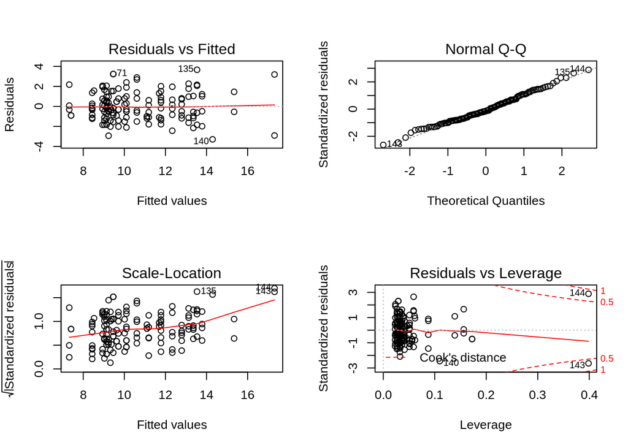

```r
plot(lm.poly.fit)
```

```r
par(par.old)
```

### 3.6.3 Analysis of non-linear transformations

References: - [Understanding Diagnostic Plots for Linear Regression Analysis](https://data.library.virginia.edu/diagnostic-plots/). - [Understanding Q-Q Plots](https://data.library.virginia.edu/understanding-q-q-plots/).

## 3.7 Is there synergy among the predictors.

```r
# lm.inter.fit <- lm(Hwt ~ Sex + Bwt + Sex:Bwt, data = dataset)
lm.inter.fit <- lm(Hwt ~ Sex * Bwt, data = dataset)
```